## Capstone Project – The Battle of Neighborhoods | Finding better localities in Toronto for placing the ATM's

### Introduction

The purpose of this Capstone Project is to help banks in understanding the socio geographic spread of Toronto across its neighborhood. It will help bank making smart and efficient decision on selecting great neighborhood out of numbers of other neighborhoods in Toranto.

Facility location is a problem of paramount importance and optimizing business operations without affecting customer service is very challenging. In the case of banking services, the location of bank branches and ATMs must match the service demands (turn around time for service, reachability etc) of the customers' and the expected quality of service is determined by the socio-economic background of the customer. Therefore, it is necessary to formulate the optimization problem so as to reflect the customers' expectations and tolerance for quality of service in a given geographical region.

The ability to do so requires clustering people living in the region into several smaller areas based on postal codes. An ideal clustering algorithm should consider the social behavior of people living in the service area and the uncertainty associated with their social behavior.

### Data Section

Following public sources were used for data collection required for the data analysis.

1. Data Link: https://en.wikipedia.org/wiki/List_of_postal_codes_of_Canada:_M

I have used dataset which was scrapped from wikipedia on Week 3. Dataset consisting of latitude and longitude, postal codes.

1. Data Link : https://www12.statcan.gc.ca/census-recensement/2016/dp-pd/hlt-fst/pd-pl/Table.cfm?Lang=Eng&T=1201&SR=1&S=22&O=A&RPP=9999&PR=0

This website is of Statistics Canada which provides the population dataacross postal codes for Canada.

1. Foursquare API Data:

We will need data about different postal codes in different neighborhoods of that Toronto. In order to gain that information we will use “Foursquare” locational information. Foursquare is a location data provider with information about all manner of venues and events within an area of interest. Such information includes venue names, locations, menus and even photos. As such, the foursquare location platform will be used as the sole data source since all the stated required information can be obtained through the API.

After finding the list of neighborhoods/postal codes, we then connect to the Foursquare API to gather information about venues inside each and every neighbourhood/postal code. For each postal code, we have chosen the radius to be 500 meter.

The data retrieved from Foursquare contained information of venues within a specified distance of the longitude and latitude of the postcodes. The information obtained per venue as follows:

1. Neighborhood
2. Neighborhood Latitude
3. Neighborhood Longitude
4. Venue
5. Name of the venue e.g. the name of a store or restaurant
6. Venue Latitude
7. Venue Longitude
8. Venue Category

We also extracted the primary classification categories used by foursquare to classify different venues in the neighbourhood. The count of venues across primary catgeories is obtained for each neighbourhood/postal code.

#### Map of Toronto

[figure not shown]

### Methodology

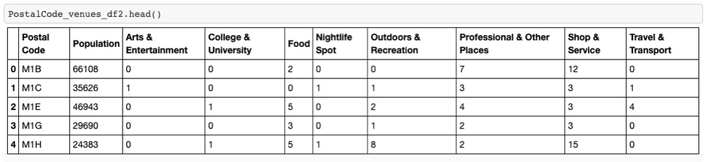

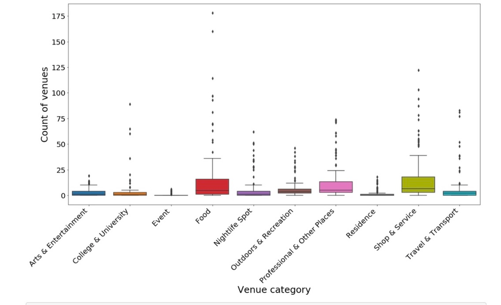

Most venues are falling under the category of Food, Shops and Service and Professional & Other places. Events and Residences have very little data and hence they can be dropped from the dimension list for clustering.

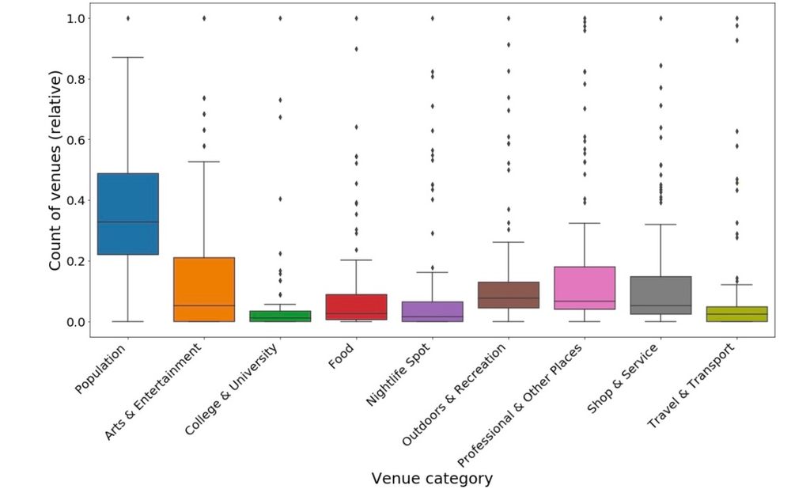

K-Means clustering is used for clustering the dataset into similar clusters. iterating through various cluster numbers, I settle for the 4 clusters as it provides the optimal results for 4 clusters.

[figure not shown]

### Results

#### Map of Clusters

[figure not shown]

### Discussion

To be fair, Foursquare data isn’t all-encompassing. I could not get data on the numbers of ATM in a geographical area. If that data was also available, then results could have been better. Also if there was opportunity to reclassify the foursquare data, then they could have been requalified based on the propensity to use ATM/spend money. Foursquare data is limited but can provide insights into planning city facilities.

### Conclusion

In this Capstone project, using k-means cluster algorithm I separated the 102 neighborhood/Postal codes into 4(Four) different clusters. We were able to create the order of priority for setting up the ATM's. The most priortized neighbourhoods were only 45 postal codes which help in reducing the locations choice for the banks.

I feel rewarded with the efforts and believe this course with all the topics covered is well worthy of appreciation. This project has shown me a practical application to resolve a real situation that has impacting personal and financial impact using Data Science tools. The mapping with Folium is a very powerful technique to consolidate information and make the analysis and decision better with confidence.

*Libraries Which are Used to Develop the Project:*

*Pandas: For creating and manipulating dataframes.*

*Folium: Python visualization library would be used to visualize the neighborhoods cluster distribution of using interactive leaflet map.*

*Scikit Learn: For importing k-means clustering.*

*JSON: Library to handle JSON files.*

*Geocoder: To retrieve Location Data.*

*Matplotlib: Python Plotting Module*